# We Rate Dogs Act Report

**By Marie-Luise Klaus**  
20/04/2019 Berlin, Germany

## 1. Introduction

**About WeRateDogs:**  
WeRateDogs is a Twitter account that humorously introduces dogs. Usually, dogs are being introduced by their name, a photo and a funny comment using doggo lingo, an internet language around the love of dogs. Dogs are mostly being classified according to their dog stage: 'doggo', 'puppo', 'pupper' or 'floofer'. Additionally, dogs are being rated by a not-so-serious number out of 10 points. Usually the number is higher than it's denominator.

https://twitter.com/dog_rates/

**Our data**  
We analysed about 1600 tweets of the WeRateDog Twitter account posted betweet November 2015 and August 2017. To identify dog breeds we used a dataset that predicted breeds from the photo using neural network image recognition software.

## 2. Most common dog breeds and dog names

When it comes to the most shared dog breeds of this account, we have a clear winner. Golden and Labrador retriever seem to be best friends of hoomans. Cooper, Lucy, Tucker, Charlie and Oliver are the most common doggie names in this account.

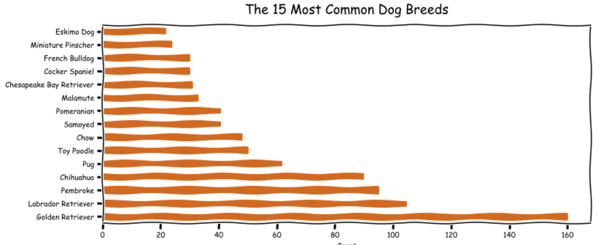

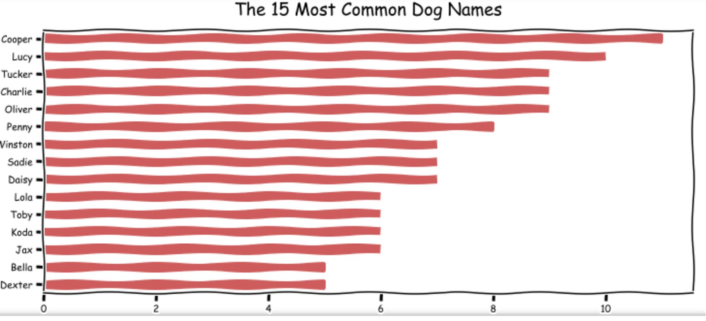

## 3. Popularity contest

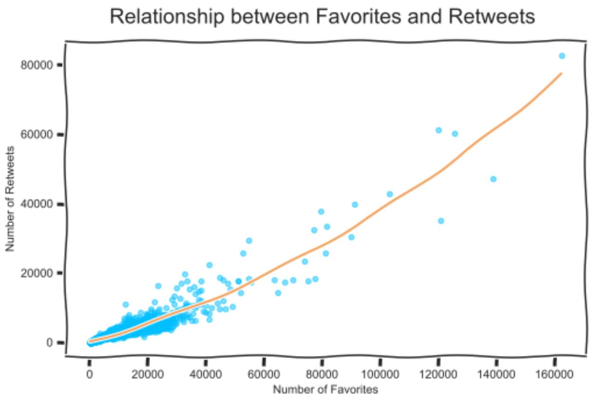

If we sort our doggies by retweet count first, and favorite count second, we found the star amongst our best friends. 162,710 hoomans favorited and 82,790 retweeted this little friend of unknown name at the time of the analysis. A round of barking applause for this Labrador.

[figure not shown]

They say, true beauty is reflected in a dog's inner soul. There is a second chance for all the doggies that don't care too much about their popularity on social media. The owner of the Twitter account rated the dogs with true dog loving expertise. Dogs were rated between 0 to 14 points out of 10. Most dogs achieved a rating between 10 to 13 out of 10 points. There were only a few that made it to the best rating of 14/10.

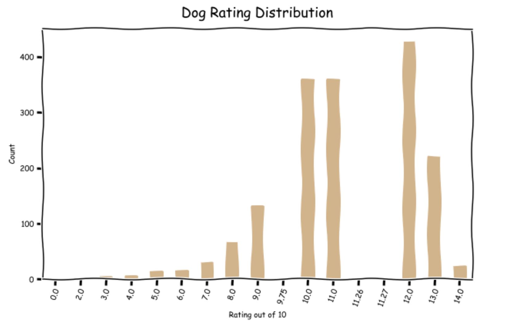

Sorting our data on the scale of the WerRateDogs acocunt first, makes one dog exceptional.

Let's introduce the winner in to you...

**~~ Bo ~~**

Bo truly stands out. Bo, also know as the first dog, is a member of the Obama family. You can read about his achievements and adventures on wikipedia https://en.wikipedia.org/wiki/Bo_(dog). Take a look at him, such a good boy.

[figure not shown]

## 4. Dog stages

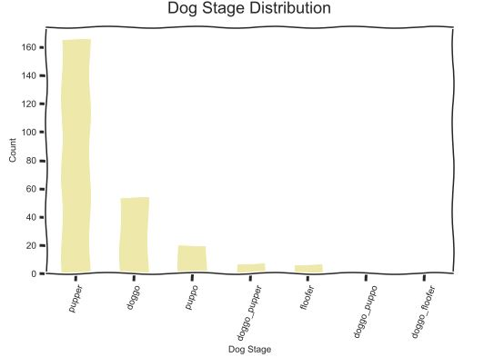

If we relate the dog stages to popularity, we find that puppos and doggos take the lead for user ratings and retweet/favorite ratings. Surprisingly, puppers slightly underperform. One theory, that still needs to be proven though, may be that the owner of We Rate Dogs values strong, brave and heroic dogs over cuteness.

However, we have to be very careful here to not jump to conclusions. The number of dog stage mentions is not high enough and unevenly distributed, so that we cannot rely on our results. Further research and data collection may bring an answer how a dog stage affects popularity.

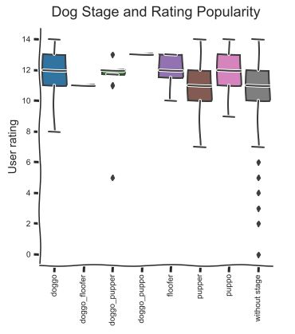

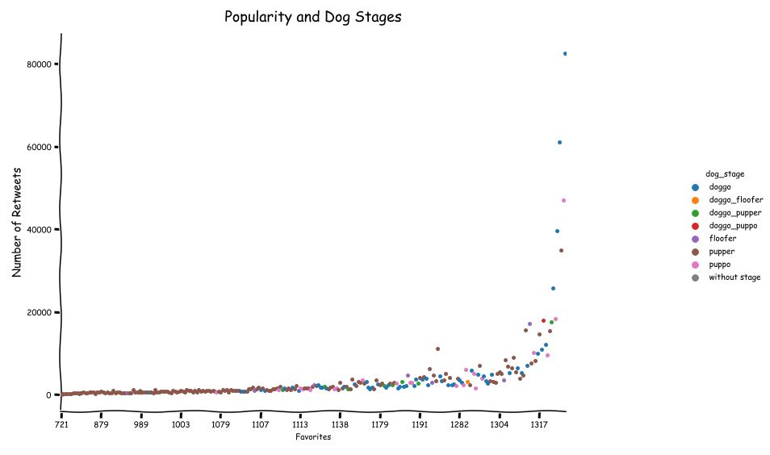

## 5. Account popularity over time

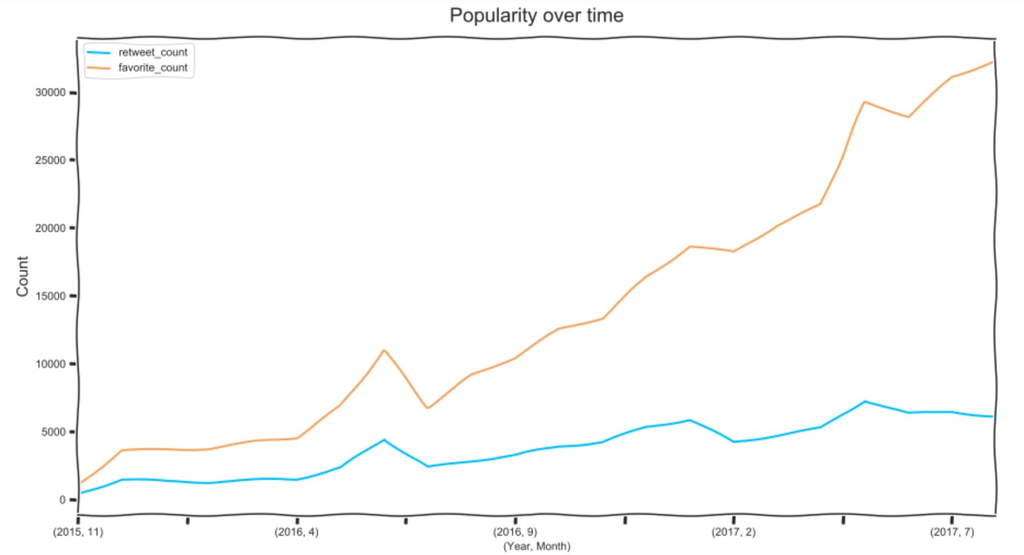

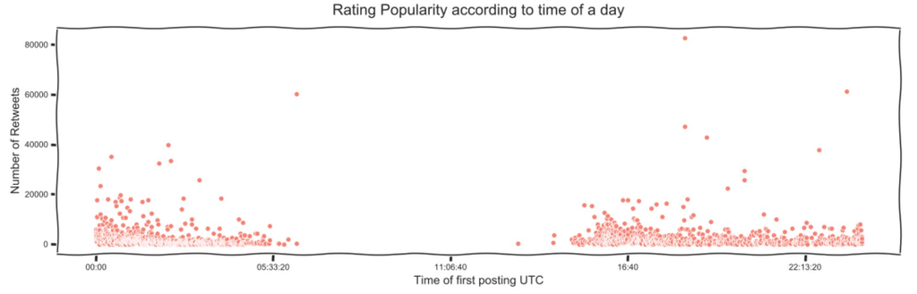

## 6. Conclusion

WeRateDogs is an internet phenomenon. Much like grumpy cat memes, doggos became more and more popular over the years. Browsing through the tweets demonstrate, dogs are loyal, brave, adorable, cute and funny. They instantly put a smile on a persons face. We Rate Dogs has proven, all pet dogs are great, no matter if they are black, white, brown, liver, tan, smol or big, floof or short-haired and pupper or puppo.

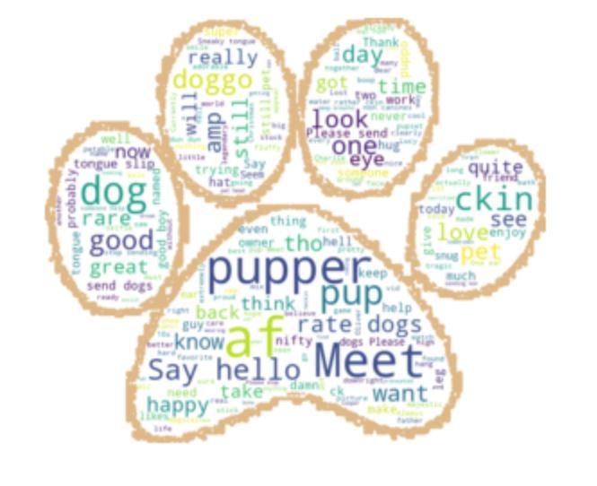